# Homework

## Question 5.13

Find two importance functions $f_1$ and $f_2$ and explain which of the two importance functions should produce the smaller variance in estimating
$$\int_1^{\infty}\frac{x^2}{\sqrt{2\pi}}e^{-x^2/2}dx$$

## Answer

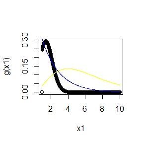

```r
m <- 10000
theta.hat <- se <-numeric(2)
g <- function(x){
  (x^2)*exp(-x^2/2)/(sqrt(2*pi))*(x>1)
}
f1 <-function(x){
  exp(-x/2)/2
}
f2 <-function(x){
  (x^2)*exp(-x/2)/16
}
x <- rexp(m,0.5)  #using f1
y <- rgamma(m,shape = 3,rate = 0.5)
#By the graphs,we compare the f1 with f2.
x1 <- seq(1,10,length = 1000)
plot(x1,g(x1),col = "black")
lines(x1,f1(x1),col = "blue")
lines(x1,f2(x1),col = "yellow")
```

```r
#the variance of f1 and f2
gf1 <- g(x)/f1(x)
gf2 <- g(y)/f2(y)
theta.hat[1] <- mean(gf1)
se[1] <- sd(gf1)
theta.hat[2] <- mean(gf2)
se[2] <- sd(gf2)
rbind(theta.hat,se)
```

```
##                [,1]     [,2]
## theta.hat 0.3975296 0.407712
## se        0.5022506 1.098439
```

we can know that $f_1$ is closer to g(x) than $f_2$,and the variance of the importance function $f_1$ is smaller than $f_2$

## Question 5.14

Obtain a Monte Carlo estimate of
$$\int_1^{\infty}\frac{x^2}{\sqrt{2\pi}}e^{-x^2/2}dx$$
by importance sampling.

## Answer

From 5.13,we can see $f_1$ is a better choice.

```r
g <- function(x){
  (x^2)*exp(-x^2/2)/(sqrt(2*pi))*(x>1)
}
f1 <-function(x){
  exp(-x/2)/2
}
m <- 10000
x <- rexp(m,0.5)
gf <- g(x)/f1(x)
theta.hat <- mean(gf)
theta.hat  #estimator
```

```
## [1] 0.3951668
```

```r
integrate(g,1,Inf) #real values
```

```
## 0.400626 with absolute error < 5.7e-07
```

The estimator is almostly equal to the real number.

## Question 5.15

Obtain the stratified importance sampling estimate in Example 5.13 and compare it with the result of Example 5.10.

## Answer

```r
M <- 10000
k <- 5    #stratified numbers
estimate <- numeric(k) #estimates
variance <- numeric(k)
g <- function(x){
  exp(-x - log(1+x^2)) * (x>0) * (x<1)
}
f <- function(x){
  exp(-x)/(1-exp(-1)) * (x>0) * (x<1)
}
for (i in 1:k){
  x <- runif(M/k,(i-1)/5,i/5)
  rate <- g(x)/f(x)
  variance[i] <- var(rate)
  estimate[i] <- mean(rate)
}
theta.hat <- mean(estimate)
sd <- sum(variance)/(M/k)
theta.hat
```

```
## [1] 0.4964537
```

```r
sd
```

```
## [1] 9.432934e-07
```

Compare with Example 5.10 $\hat{\theta}=0.5257801,sd = 0.0970314$ the variance of the result is far less than exmple 5.10

## Question 6.5

Use a Monte Carlo experiment to estimate the coverage probability of the t-interval for random samples of $\chi^2{(2)}$ data with sample size n=20.Compare your t-interval results with the simulation results in Example 6.4.

## Answer

As we konw ,$X_1,...X_n$ iid copies of $\chi^2(2)$,$EX=2$

```r
n <- 20
alpha <- 0.05
k <- 1000
# 6.5 confidence interval
calci <- function(n,alpha){
  confidence.int <- numeric(2)
  x <- rchisq(n,df = 2)
  theta.hat <- mean(x)
  d <- var(x)
  UCL <- theta.hat + qt(1-alpha/2,df = n-1)*sqrt(d/n) #upper confidence limit
  LCL <- theta.hat - qt(1-alpha/2,df = n-1)*sqrt(d/n) #lower confidence limit
  confidence.int[1] <- LCL
  confidence.int[2] <- UCL
  return(confidence.int)
}
counts <- numeric(k)
for (i in 1:k){
  cfint <- calci(n,alpha)
  if (cfint[1]<2 & cfint[2]>2){
    counts[i] <- 1
  }
}
# Example 6.4
results <- replicate(k,expr = {
  x <- rnorm(n,mean = 0,sd = 2)
  (n-1) * var(x)/qchisq(alpha,df = n-1)
})

mean(counts)
```

```
## [1] 0.927
```

```r
mean(results > 4)
```

```
## [1] 0.948
```

## Question 6.A

Use Monte Carlo simulation to investigate whether the empirical Type I error rate of the t-test is approximately equal to the nominal significance level $\alpha$ ,when the sampled population is non-normal. Discuss the simulation results for the cases where the sampled population is (i)$\chi^2(x)$ (ii)$Uniform(0,2)$ (iii)$Exponential(rate = 1$)

## Answer

```r
n <- 20
alpha <- 0.05
mu1 <- mu2 <- mu3 <-1

m <- 10000
p1<- p2 <- p3 <- numeric(m)
for (i in 1:m){
  x1 <- rchisq(n,df = 1)
  x2 <- runif(n,0,2)
  x3 <- rexp(n,1)
  x1test <- t.test(x1,alternative = "greater",mu = mu1) #(i)chi-square
  x2test <- t.test(x2,alternative = "greater",mu = mu2) #Uniform(0,2)
  x3test <- t.test(x3,alternative = "greater",mu = mu3) #exp(1)
  p1[i] <- x1test$p.value
  p2[i] <- x2test$p.value
  p3[i] <- x3test$p.value
}
p1.hat <- mean(p1 < alpha)
se1.hat<- sqrt(p1.hat * (1-p1.hat) / m)
p2.hat <- mean(p2 < alpha)
se2.hat<- sqrt(p2.hat * (1-p2.hat) / m)
p3.hat <- mean(p3 < alpha)
se3.hat<- sqrt(p3.hat * (1-p3.hat) / m)
print(c(p1.hat,se1.hat))
```

```
## [1] 0.012500000 0.001111024
```

```r
print(c(p2.hat,se2.hat))
```

```
## [1] 0.052200000 0.002224301
```

```r
print(c(p3.hat,se3.hat))
```

```
## [1] 0.017700000 0.001318587
```

Hence,we can see the $\chi^2(x)$ is more significant than other two random variables.

## Question

Considering $m=1000$ hypotheses, under the null hypothesis, the $p\sim{}U(0,1)$, and under the opposing hypothesis, the $p\sim{}beta(0.1,1)$.Bonferroni correction and BH correction are applied to the generated P-values, and the comparison with $\alpha = 0.1$ determines whether the null hypothesis is rejected.

## Answer

```r
m <- 1000
alpha <- 0.1
#generate p-value
fwer1 <- fdr1 <- tpr1 <- numeric(m)
fwer2 <- fdr2 <- tpr2 <- numeric(m)
orignalp <- function(m){
  p0 <- runif(m*0.95)
  p1 <- rbeta(m*0.05,0.1,1)
  return(c(p0,p1))
}
#compute FWER
fwer <- function(alpha,x){
  k <- 0
  for (i in length(x)){
    if (x[i]<alpha){
      k <- k + 1
    }
  }
  1-(1-alpha/length(x))^(length(x)-k)
}
#compute FDR
fdr <- function(origvalues,adjust.val){
  FN <- 0
  for (i in 1:length(origvalues)){
    if (origvalues[i] < 0.1 & adjust.val[i] > 0.1){
      FN <- FN + 1
    }
  }
  FN / sum(adjust.val > 0.1)
}
#compute TPR
tpr <- function(origvalues,adjust.val){
  TP <- 0
  for (i in length(origvalues)){
    if (origvalues[i] < 0.1 & adjust.val[i] < 0.1){
      TP <- TP + 1
    }
  }
  TP / sum(origvalues < 0.1)
}
for (i in 1:m){
  pvalues <- orignalp(1000)
  #generate adjust-pvalues
  sortpvalues <- sort(pvalues)
  bonvalues <- p.adjust(pvalues,method = "bonferroni")
  bhvalues <- p.adjust(sortpvalues,method = "BH")
  fwer1[i] <- fwer(alpha,bonvalues)
  fwer2[i] <- fwer(alpha,bhvalues)
  fdr1[i] <- fdr(pvalues,bonvalues)
  fdr2[i] <- fdr(sortpvalues,bhvalues)
  tpr1[i] <- tpr(pvalues,bonvalues)
  tpr2[i] <- tpr(sortpvalues,bhvalues)
}
df <- data.frame(
  FWER = c(mean(fwer1),mean(fwer2)),
  FDR = c(mean(fdr1),mean(fdr2)),
  TPR = c(mean(tpr1),mean(tpr2)),
  row.names = c("Bonferroni","B-H"),
  stringsAsFactors=FALSE
)
print(df)
```

```
##                  FWER       FDR         TPR
## Bonferroni 0.09512865 0.1175016 0.003158395
## B-H        0.09516711 0.1072230 0.000000000
```

## Question

Suppose the population has the exponential distribution with rate $\lambda$,then the MLE of $\hat\lambda$ is $\hat\lambda = \frac{1}{\bar{x}}$,where $\bar{x}$ is the sample mean.The expectation of $\hat\lambda$ is $\lambda n/(n - 1)$,the standard error $\lambda$ is $\lambda n/[(n - 1)\sqrt{n-2}]$.Conduct a simulation study to verify the performance of the bootstrap method. Where the true value of $\lambda = 2$,the sample size $n = 5,10,20$,the number of bootstrap replicates $B =1000$,the simulations are repeated for $m = 1000$ times. Compare the mean bootstrap bias and bootstrap standard error with the theoretical ones.Comment on the results.

## Answer

```r
# theoretical bias and se
theoretical <- function(n,lambda){
  bias <- lambda/(n-1)
  se <- lambda *n/((n-1)*sqrt(n-2))
  return(c(bias,se))
}
# bias and se by the bootstrap
boots <- function(x,n,lambda,B){
  thetastar <- numeric(B)
  for (i in 1:B){
    xstar <- sample(x,replace=TRUE)
    thetastar[i] <- 1/mean(xstar)
  }
  round(c(bias=mean(thetastar)-1/mean(x),se.boot = sd(thetastar)))
}
#repeat the sumulations for 1000 times
result <- function(n){
  bias <- se <- numeric(1000)
  lambda <- 2
  B <- 1000
  for (i in 1:1000){
    x <- rexp(n,lambda)
    bias[i] <- boots(x,n,lambda,B)[1]
    se[i] <- boots(x,n,lambda,B)[2]
  }
  c(mean(bias),mean(se))
}
bias <- data.frame(
  bootstrap = c(result(5)[1],result(10)[1],result(20)[1]),
  theor = c(theoretical(5,2)[1],theoretical(10,2)[1],theoretical(20,2)[1]),
  row.names = c(5,10,20)
)
se <- data.frame(
  bootstrap = c(result(5)[2],result(10)[2],result(20)[2]),
  theor = c(theoretical(5,2)[2],theoretical(10,2)[2],theoretical(20,2)[2]),
  row.names = c(5,10,20)
)
print(bias)
```

```
##    bootstrap     theor
## 5      0.463 0.5000000
## 10     0.052 0.2222222
## 20     0.000 0.1052632
```

```r
print(se)
```

```
##    bootstrap     theor
## 5      3.159 1.4433757
## 10     0.833 0.7856742
## 20     0.434 0.4962153
```

## Question

Obtain a bootstrap t confidence interval estimate for the correlation statistic in Example 7.2 (law data in bootstrap).

## Answer

```r
data(law,package = "bootstrap")
boot.t.ci <-
function(x, B = 500, R = 100, level = .95, statistic){
  #compute the bootstrap t CI
  x <- as.matrix(x); n <- nrow(x)
  stat <- numeric(B); se <- numeric(B)
  boot.se <- function(x, R, f) {
    #local function to compute the bootstrap
    #estimate of standard error for statistic f(x)
    x <- as.matrix(x); m <- nrow(x)
    th <- replicate(R, expr = {
      i <- sample(1:m, size = m, replace = TRUE)
      f(x[i, ])
      })
    return(sd(th))
  }
  for (b in 1:B) {
    j <- sample(1:n, size = n, replace = TRUE)
    y <- x[j, ]
    stat[b] <- statistic(y)
    se[b] <- boot.se(y, R = R, f = statistic)
  }
  stat0 <- statistic(x)
  t.stats <- (stat - stat0) / se
  se0 <- sd(stat)
  alpha <- 1 - level
  Qt <- quantile(t.stats, c(alpha/2, 1-alpha/2), type = 1)
  names(Qt) <- rev(names(Qt))
  CI <- rev(stat0 - Qt * se0)
}
stat <- function(x,i){cor(x[i,1],x[i,2])}
ci <- boot.t.ci(law,statistic = stat,B=2000,R=200)
print(ci)
```

```
##       2.5%      97.5%
## -0.3016521  0.9769754
```

## Question

Compute 95% bootstrap confidence intervals for the mean time between failures $\frac{1}{\lambda}$ by the standard normal, basic, percentile,and BCa methods.Compare the intervals and explain why they may differ.

## Answer

```r
n <- 10;
m <- 1000
obser <- c(3,5,7,18,43,85,91,98,100,130,230,487)
set.seed(12345)
boot.mean <- function(x,i) mean(x[i])
ci.norm <- ci.basic <- ci.perc <- ci.bca <- matrix(NA,1,2)
de <- boot(data=obser,statistic = boot.mean,R=2000)
ci <- boot.ci(de,type = c("norm","basic","perc","bca"))
print(ci)
```

```
## BOOTSTRAP CONFIDENCE INTERVAL CALCULATIONS
## Based on 2000 bootstrap replicates
##
## CALL :
## boot.ci(boot.out = de, type = c("norm", "basic", "perc", "bca"))
##
## Intervals :
## Level      Normal              Basic
## 95%   ( 34.4, 181.4 )   ( 24.3, 170.1 )
##
## Level     Percentile            BCa
## 95%   ( 46.1, 191.9 )   ( 55.6, 224.7 )
## Calculations and Intervals on Original Scale
## Some BCa intervals may be unstable
```

```r
#compute the  mean lengths of the intervals
norm.len <- basic.len <- perc.len <- bca.len <- numeric(m)
for (i in 1:m){
  ci <- boot.ci(de,type = c("norm","basic","perc","bca"))
  norm.len[i] <- ci$norm[3]-ci$norm[2]
  basic.len[i] <- ci$basic[5]-ci$basic[4]
  perc.len[i] <- ci$perc[5]-ci$perc[4]
  bca.len[i] <- ci$bca[5]-ci$bca[4]
}
print(c(mean(norm.len),mean(basic.len),mean(perc.len),mean(bca.len)))
```

```
## [1] 147.0029 145.8270 145.8270 169.1094
```

Although the confidence intervals using the basic and percent methods are the same length,we can see that the upper and lower bounds for each confidence interval are different.I think this is mainly due to the small amount of data in the original sample and a certain bias to the left.

## Question

Refer to Exercise 7.7. Obtain the jackknife estimates of bias and standard error of $\hat{\theta}$.

## Answer

```r
attach(scor)
data <- as.matrix(scor)
n <- length(data[,1])
#the function of theta
scores.fun <- function(x,i){
  eigen(cov(x))$values[1]/sum(eigen(cov(x))$values)
}
theta.hat <- eigen(cov(data))$values[1]/sum(eigen(cov(data))$values)
theta.jack <- numeric(n)
for (i in 1:n){
  theta.jack[i] <- scores.fun(data[-i,])
}
bias.jack <- (n-1)*mean((theta.jack)-theta.hat)
se.jack <- sqrt((n-1)*mean((theta.jack-theta.hat)^2))
round(c(original=theta.hat,bias.jack=bias.jack,se.jack=se.jack),3)
```

```
##  original bias.jack   se.jack
##     0.619     0.001     0.050
```

## Question

In Example 7.18,leave-one-out(n-fold) cross validation was used to select the best fitting model.Use leave-two-out cross validation to compare the models.

## Answer

```r
attach(ironslag)
set.seed(1234)
n <- length(magnetic)
e1 <- e2 <- e3 <-e4 <- matrix(NA,n,n-1)
# for n-fold cross validation
# fit models on leave-two-out samples
for (k in 1:n){
  y <- magnetic[-k]
  x <- chemical[-k]
  for (j in 1:(n-1)){
    z <- y[-j]
    w <- x[-j]

    J1 <- lm( z~ w)
    yhat1 <- J1$coef[1] + J1$coef[2] * x[j]
    e1[k,j] <- y[j] - yhat1

    L2 <- lm( z ~ w + I(w^2) )
    yhat2 <- L2$coef[1] + L2$coef[2] * x[j] +
             L2$coef[3] * x[j]^2
    e2[k,j] <- y[j] - yhat2

    L3 <- lm( log(z) ~ w )
    logyhat3 <- L3$coef[1] + L3$coef[2] * x[j]
    yhat3 <- exp( logyhat3 )
    e3[k,j] <- y[j] - yhat3

    L4 <- lm( log(z) ~ log(w) )
    logyhat4 <- L4$coef[1] + L4$coef[2] * log(x[j])
    yhat4 <- exp( logyhat4 )
    e4[k,j] <- y[j] - yhat4
  }
}
c(mean(e1^2),mean(e2^2),mean(e3^2),mean(e4^2))
```

```
## [1] 19.57227 17.87018 18.45491 20.46718
```

We can see that L2 is the best model.

```r
plot(L2$fit, L2$res)#residuals vs fitted values
abline(0, 0)        #reference line
qqnorm(L2$res)      #normal probability plot
qqline(L2$res)      #reference line
```

[output not shown]

## Question

Proof the Stationarity of Metropolis-Hastings sampler Algorithm in continuous situation.

## Answer

If the support $S$ of the target distribution is a continuous set, note $f$ as the probability density function of the target distribution.Note:
$$Q:proposal \
distribution \ function\\
q(·|x):proposal\ probability \ density\ function ,for\ any\ x$$
Then,the acceptance probability$\alpha(x,y)=min \{1,\frac{f(y)q(x|y)}{f(x)q(y|x)}\}$ we have $f(x)q(y|x)>0,for\ all\ (x,y)$,so the Markov chain transition kernel is
$$p(x,y)=q(y|x)\alpha(x,y)=q(y|x)min\{1,\frac{f(y)q(x|y)}{f(x)q(y|x)}\}$$
Then,
$$p(x,y)f(x)=f(x)q(y|x)\alpha(x,y)=p(y,x)f(y)$$
Integrate both sides of the Detailed Balance Equation,we have
$$\int p(x,y)f(x)dx=\int p(y,x)f(y)dx
\Longleftrightarrow f(y)=\int p(x,y)f(x)dx$$
Thus,we know that $f$ is stationary distribution from the definition of stationary distribution.

## Question 8.1

Implement the two-sample Cramér-von Mises test for equal distributions as a permutation test.Apply the test to the data in Examples 8.1 and 8.2.

## Answer

```r
set.seed(123)
attach(chickwts)
x <- sort(as.vector(weight[feed == "soybean"]))
y <- sort(as.vector(weight[feed == "linseed"]))
z <- c(x,y)
detach(chickwts)
r<-999
dos <- numeric(r)
#the cramer-von Mises Statistic
w2 <- function(n1,m1){
  sd1 <- numeric(n)
  sd2 <- numeric(m)
  n2 <- sort(n1)
  m2 <- sort(m1)
  for (j in 1:n){
      k1 <- 0
      for (k in 1:m){
        if (n2[j] <= m2[k]){
          k1 <- k1 + 1
        }
      }
      sd1[j] <- ((j/n)-(k1/m))^2
  }
  for (j1 in 1:m){
      k2 <- 0
      for (k3 in 1:n){
        if (m2[j1] <= n2[k3]){
          k2 <- k2 + 1
        }
      }
      sd2[j1] <- ((j1/m)-(k2/n))^2
    }
  m*n*(sum(sd1)+sum(sd2))/(m+n)^2
}
n <- length(x)
m <- length(y)
l <- 1:length(z)
for (i in 1:r){
  sam <- sample(l,n,replace = FALSE)
  x1 <- z[sam]
  x2 <- z[-sam]
  dos[i] <- w2(x1,x2)
}
do <-w2(x,y)
p <- mean(c(do,dos) >= do)
p
```

```
## [1] 0.607
```

Here the sample evidence do not supports the alternative hypothesis that the distributions differ.

## Question 8.3

The Count 5 test for equal variances in Section 6.4 is based on the maximum number of extreme points. Example 6.15 shows that the Count 5 criterion is not applicable for unequal sample sizes. Implement a permutation test for equal variance based on the maximum number of extreme points that applies when sample sizes are not necessarily equal.

## Answer

```r
set.seed(1234)
c5t <- function(x,y){
  n <- length(x)
  m <- length(y)
  X <- x - mean(x)
  Y <- y - mean(y)
  outx <- sum(X > max(Y)) + sum(X < min(Y))
  outy <- sum(Y > max(X)) + sum(Y < min(X))
  return(c(outx,outy))
}
nu1 <- 20
nu2 <- 30
mu1 <- mu2 <- 0
sigma1 <- sigma2 <- 1
r <- 999
D <- matrix(NA,r,2)
x <- rnorm(nu1, mu1, sigma1)
y <- rnorm(nu2, mu2, sigma2)
N <- c(x,y)
l <- 1:length(N)
DO <- c5t(x,y)
for (i in 1:r){
  n1 <- sample(l,length(x),replace = FALSE)
  x1 <- N[n1]
  y1 <- N[-n1]
  pt <- c5t(x1,y1)
  D[i,1] <- pt[1]
  D[i,2] <- pt[2]
}
K1 <- 1
for (i in 1:r){
  if (D[i,1]>=DO[1] & D[i,2] >= DO[2]){
    K1 <- K1 + 1
  }
}
p <- K1/1000
p
```

```
## [1] 0.336
```

We can know that p values >0.05,do not reject the null hypothesis.

```r
data(schools) # a real dataset

N <- 1e4
J <- nrow(schools)
y <- schools$estimate
sigma.y <- schools$sd
data <- list ("N", "J", "y", "sigma.y")

inits <- function(){
  list(theta = rnorm(J, 0, 100), mu.theta = rnorm(1, 0, 100),
    sigma.theta = runif(1, 0, 100))
}

schools.sim <- bugs(data, inits, model.file = "schools.txt",
                    parameters = c("theta", "mu.theta", "sigma.theta"),
                    n.chains = 3, n.iter = N, codaPkg=TRUE)
```

## Question

Consider a model $P(Y=1|X_1,X_2,X_3)=\frac{exp(a+b_1X_1+b_2X_2+b_3X_3)}{1+exp(a+b_1X_1+b_2X_2+b_3X_3)}$,where $X_1 \sim P(1) ,X_2 \sim Exp(1),and\ X_3 \sim B(1,0.5)$ 1) Design a specify function which produces the output. 2) Use the function to compare a with $-logf_0$

## Answer

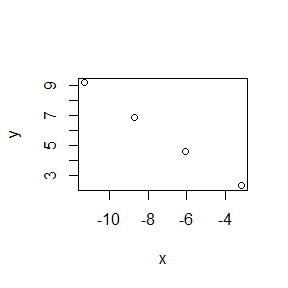

```r
set.seed(12345)
ln <- function(N,b1,b2,b3,f0){
  x1 <- rpois(N,1)
  x2 <- rexp(N,1)
  x3 <- sample(0:1,N,replace = TRUE)
  p <- function(alpha){
  tmp <- exp(-alpha-b1*x1-b2*x2-b3*x3)
    pval <- 1/(1+tmp)
    mean(pval) - f0
  }
  solution <- uniroot(p,c(-20,0)) #let p value < 0.1
  solution$root
}
N <- 10e6
b1 <- 0;b2 <- 1;b3 <- -1
f0 <- 0.1
a1 <- ln(N,b1,b2,b3,f0)
a2 <- ln(N,b1,b2,b3,f0/10)
a3 <- ln(N,b1,b2,b3,f0/100)
a4 <- ln(N,b1,b2,b3,f0/1000)
x <- c(a1,a2,a3,a4)
y <- c(-log(f0),-log(f0/10),-log(f0/100),-log(f0/1000))
plot(x,y)
```

Thus,we can see that $-logf_0$ is linear correlated with a.

## Question 9.4

Implement a random walk Metropolis sampler for generating the standard Laplace distribution.For the increment, simulate from a normal distribution.Compare the chains generated when different variances are used for the proposal distribution.Also,compute the acceptance rates of each chain.

## Answer

```r
set.seed(12345)
f <- function(x) (exp(-abs(x)))/2
set.seed(12345)
rw.Metropolis <- function(sigma, x0, N) {
    x <- numeric(N)
    x[1] <- x0
    u <- runif(N)
    k <- 0
    for (i in 2:N) {
      y <- rnorm(1, x[i-1], sigma)
        if (u[i] <= (exp(-abs(y))/exp(-abs(x[i-1]))))
        x[i] <- y  else {
            x[i] <- x[i-1]
            k <- k + 1
        }
      }
    return(list(x=x, k=N-k))
    }
N <- 2000
sigma <- c(0.05,1,4,16) #four different sigma

x0 <- 5
rw1 <- rw.Metropolis(sigma[1], x0, N)
rw2 <- rw.Metropolis(sigma[2], x0, N)
rw3 <- rw.Metropolis(sigma[3], x0, N)
rw4 <- rw.Metropolis(sigma[4], x0, N)

#number of candidate points accepted
acceptance <- data.frame(sigma=sigma,acceptance=c(rw1$k, rw2$k, rw3$k, rw4$k))
knitr::kable(acceptance)
```

| sigma | acceptance |
| --- | --- |
| 0.05 | 1965 |
| 1.00 | 1373 |
| 4.00 | 681 |
| 16.00 | 218 |

Compare the chains by the line plot.

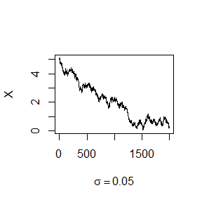

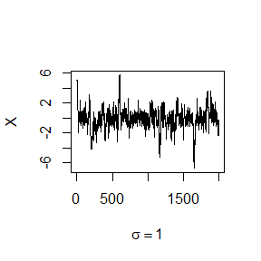

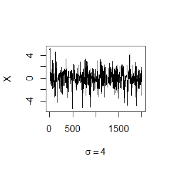

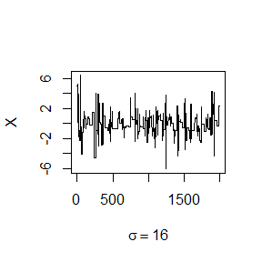

```r
rw <- cbind(rw1$x, rw2$x, rw3$x,  rw4$x)
for (j in 1:4) {
    plot(rw[,j], type="l",
          xlab=bquote(sigma == .(round(sigma[j],3))),
          ylab="X", ylim=range(rw[,j]))
}
```

We can see that the chain in the third plot($\sigma=4$) is mixing well and converging to the target distribution after a short period.

## Question 9.7

Implement a Gibbs sampler to generate a bivariate normal chain $(X_t, Y_t)$ with zero means,unit standard deviations,and correlation 0.9.Plot the generated sample after discarding a suitable burn-in sample.Fit a simple linear regression model $Y = β_0 + β_1X$ to the sample and check the residuals of the model for normality and constant variance.

## Answer

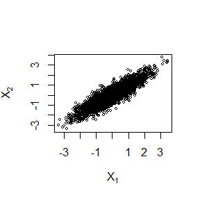

```r
#initialize constants and parameters
N <- 5000 #length of chain
burn <- 1000 #burn-in length
X <- matrix(0, N, 2) #the chain, a bivariate sample
rho <- 0.9 #correlation
mu1 <- 0
mu2 <- 0
sigma1 <- 1
sigma2 <- 1
s1 <- sqrt(1-rho^2)*sigma1
s2 <- sqrt(1-rho^2)*sigma2
# generate the chain
X[1, ] <- c(mu1, mu2) #initialize
for (i in 2:N) {
  x2 <- X[i-1, 2]
  m1 <- mu1 + rho * (x2 - mu2) * sigma1/sigma2
  X[i, 1] <- rnorm(1, m1, s1)
  x1 <- X[i, 1]
  m2 <- mu2 + rho * (x1 - mu1) * sigma2/sigma1
  X[i, 2] <- rnorm(1, m2, s2)
}
b <- burn + 1
x <- X[b:N, ]
plot(x, main="", cex=.5, xlab=bquote(X[1]),ylab=bquote(X[2]), ylim=range(x[,2]))
```

Now fit the simple linear regression model

```r
Y <- x[,2]
X <- x[,1]
dat <- data.frame(x)
lreg <- lm(Y~X,data=dat)
#normality test
res <- residuals(lreg)
shapiro.test(res) # p value > 0.05,we do not reject the null hypothesis
```

```
##
##  Shapiro-Wilk normality test
##
## data:  res
## W = 0.9992, p-value = 0.06737
```

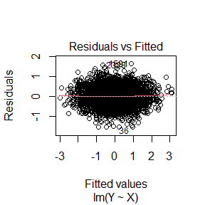

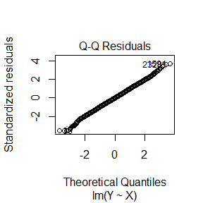

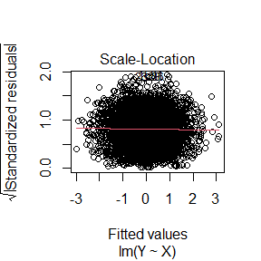

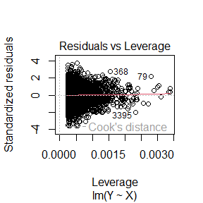

```r
#plot(density(res))

plot(lreg)
```

Thus,the residuals have the normality and constant variance.

## Question 9.10

Refer to Example 9.1. Use the Gelman-Rubin method to monitor convergence of the chain, and run the chain until the chain has converged approximately to the target distribution according to $\hat{R}<1.2$.Also use the coda package to check for convergence of the chain by the Gelman-Rubin method.

## Answer

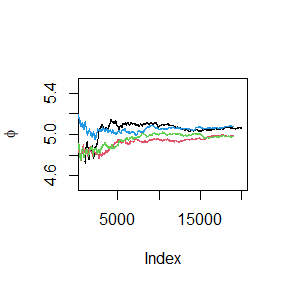

```r
f <- function(x, sigma) {
  if (any(x < 0)) return (0)
  stopifnot(sigma > 0)
  return((x / sigma^2) * exp(-x^2 / (2*sigma^2)))
}
Gelman.Rubin <- function(psi) {
    # psi[i,j] is the statistic psi(X[i,1:j])
    # for chain in i-th row of X
    psi <- as.matrix(psi)
    n <- ncol(psi)
    k <- nrow(psi)

    psi.means <- rowMeans(psi)     #row means
    B <- n * var(psi.means)        #between variance est.
    psi.w <- apply(psi, 1, "var")  #within variances
    W <- mean(psi.w)               #within est.
    v.hat <- W*(n-1)/n + (B/n)     #upper variance est.
    r.hat <- v.hat / W             #G-R statistic
    return(r.hat)
}

chisq.chain <- function(sigma, N){
    #with chisq(df=x) proposal distribution
    #and starting value X1
    x <- rep(0, N)
    x[1] <- rchisq(1,df=1)
    u <- runif(N)

    for (i in 2:N) {
      xt <- x[i-1]
      y <- rchisq(1,df = xt)     #candidate point
      r1 <- f(y,sigma) * dchisq(xt,df = y)
      r2 <- f(xt,sigma) * dchisq(y,df = xt)
      if (u[i] <= r1/r2) x[i] <- y else
        x[i] <- xt
    }
    return(x)
}

    sigma <- 4    #parameter of proposal distribution
    k <- 4          #number of chains to generate
    n <- 20000     #length of chains
    b <- 1000       #burn-in length

    #generate the chains
    X <- matrix(0, nrow=k, ncol=n)
    for (i in 1:k)
        X[i, ] <- chisq.chain(sigma, n)

    #compute diagnostic statistics
    psi <- t(apply(X, 1, cumsum))
    for (i in 1:nrow(psi))
        psi[i,] <- psi[i,] / (1:ncol(psi))
#plot psi for the four chains
for (i in 1:k)
  if(i==1){
    plot((b+1):n,psi[i, (b+1):n],ylim=c(4.5,5.5), type="l",
        xlab='Index', ylab=bquote(phi))
  }else{
  lines(psi[i, (b+1):n], col=i)
  }
```

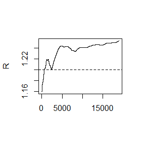

```r
    #plot the sequence of R-hat statistics
    rhat <- rep(0, n)
    for (j in (b+1):n)
        rhat[j] <- Gelman.Rubin(psi[,1:j])
    plot(rhat[(b+1):n], type="l", xlab="", ylab="R")
    abline(h=1.2, lty=2)
```

## Question

Let $X_1,\ldots,X_n \stackrel{i.i.d}{\sim}Exp(\lambda)$,we only know that $X_i$ belong to some intervals $[u_i,v_i]$. (1)use MLE and EM algorithm to estimate $\lambda$,and prove the convergence of EM algorithm to MLE. (2)observed valus:(11,12),(8,9),(27,28),(13,14),(16,17),(0,1),(23,24),(10,11),(24,25),(2,3).Implementing numerical solutions for MLE and EM algorithms

## Answer

(1)MLE The likelihood function
$$L(\theta)
= \prod_{i=1}^nP_\lambda (u_i\leq X_i \leq v_i),when\ X_1 ,\ldots,
Xi\sim exp(\lambda)$$
$$\begin{aligned}
l(\theta) &= log\prod_{i=1}^nP_\lambda (u_i\leq X_i \leq v_i)\\
&=\Sigma_{i=1}^n log(1-e^{\lambda(u_i-v_i)})e^{-\lambda u_i} \\
&= \Sigma_{i=1}^{n} [-\lambda u_i +log(1-e^{\lambda(u_i-v_i)})]
\end{aligned}$$
Then,
$$H(\lambda)=\frac{d}{d\lambda}l(\lambda)=-\Sigma_{i=1}^{n}u_i+\Sigma_{i=1}^{n}\frac{-(u_i-v_i)e^{\lambda(u_i-v_i)}}{1-e^{\lambda(u_i-v_i)}}\\
\frac{d}{d\lambda}H(\lambda)=\Sigma_{i=1}^{n}\frac{-(u_i-v_i)^2e^{\lambda(u_i-v_i)}}{1-e^{\lambda(u_i-v_i)}}<0$$
Thus,H($\lambda$) is a decreasing function,so when set $\lambda^*$ $s.t.$
$$H(\lambda)=-\Sigma_{i=1}^{n}u_i+\Sigma_{i=1}^{n}\frac{-(u_i-v_i)e^{\lambda(u_i-v_i)}}{1-e^{\lambda(u_i-v_i)}}=0$$
we get the mle $\lambda^*$
$$H(\lambda)=\frac{d}{d\lambda}l(\lambda)=-\Sigma_{i=1}^{n}u_i+\Sigma_{i=1}^{n}\frac{-(u_i-v_i)e^{\lambda(u_i-v_i)}}{1-e^{\lambda(u_i-v_i)}}$$

```r
#mle generates the numerical solution
#compute log likelihood function root
obj.lambda <- function(left,right,lambda){
  k <- 0
  for (i in 1:length(left)){
    k <- k + (left[i] - right[i])*exp(lambda*(left[i] - right[i]))/(1-exp(lambda*(left[i] - right[i])))
  }
  sum(left) + k
}
left <- c(11,8,27,13,16,0,23,10,24,2)
right <- c(12,9,28,14,17,1,24,11,25,3)
u <- uniroot(obj.lambda,lower = 0.001,upper = 10e5,left = left,right = right)
result <- u$root
result
```

```
## [1] 0.07194874
```

(2)EM observed data:$u_i v_i ,i=1,,n$ complete data:$u_i v_i s_i,i=1,,n$,$s_i$ is the real value. observed likelihood function is
$$L_o(p)=\prod_{i=1}^n(e^{-\lambda u_i}-e^{-\lambda
v_i})$$
$$L(\lambda |
u,s,v)= \lambda^n\prod_{i=1}^{n}e^{-\lambda s_i}$$
E-step When the $s_i$ is unknown,$f_{s|u,v}(s|u,v)=\frac{\lambda e^{-\lambda s}}{e^{-\lambda u_i}-e^{\lambda v_i}}$
$$\begin{aligned}
\hat{s_i}&=E(s_i|u,v) \\
&=\frac{1}{\lambda}+\frac{u_ie^{-\lambda u_i}-v_ie^{\lambda
v_i}}{e^{-\lambda u_i}-e^{\lambda v_i}}
\end{aligned}$$

$$\begin{aligned}
Q(\lambda)&=E[logL(s|u,v,\hat{\lambda})] \\
&=nlog{\lambda}-\lambda \Sigma_{i=1}^{n}E(s_i|u,v,\hat{\lambda}) \\
&=nlog{\lambda}-\lambda
\Sigma_{i=1}^{n}[\frac{1}{\hat{\lambda}}+\frac{u_ie^{{-\hat{\lambda}}
u_i}-v_ie^{{-\hat{\lambda}} v_i}}{e^{-{\hat{\lambda}}
u_i}-e^{-{\hat{\lambda}} v_i}}]
\end{aligned}$$

M-step $\frac{d}{d\lambda}Q(\lambda)=\frac{n}{\lambda}-\Sigma_{i=1}^{n}[\frac{1}{\hat{\lambda}}+\frac{u_ie^{{-\hat{\lambda}} u_i}-v_ie^{{-\hat{\lambda}} v_i}}{e^{-{\hat{\lambda}} u_i}-e^{-{\hat{\lambda}} v_i}}]=0$ $\lambda_1 = \frac{n}{\Sigma_{i=1}^{n} [\frac{1}{\hat{\lambda}}+\frac{u_ie^{{-\hat{\lambda}} u_i}-v_ie^{{-\hat{\lambda}} v_i}}{e^{-{\hat{\lambda}} u_i}-e^{-{\hat{\lambda}} v_i}}]}$ We can see that
$$\lambda_{j+1} = \frac{n}{\Sigma_{i=1}^{n}
[\frac{1}{\lambda_{j}}+\frac{u_ie^{-\lambda_{j} u_i}-v_ie^{-\lambda_{j}
v_i}}{e^{-\lambda_{j} u_i}-e^{-\lambda_{j} v_i}}]}$$
According the equation above,we assume that $\lambda_{j+1}=\lambda_{j}$, $\Sigma_{i=1}^{n} \frac{\lambda_{j}u_ie^{-\lambda_{j} u_i}-\lambda_{i}v_ie^{-\lambda_{j} v_i}}{e^{-\lambda_{i} u_i}-e^{-\lambda_{i} v_i}}=\Sigma_{i=1}^{n} \frac{\lambda_{j}u_i-\lambda_{i}v_ie^{\lambda_{j} (u_i-v_i)}}{1-e^{\lambda_{i} (u_i-v_i)}}=\Sigma_{i=1}^{n} [\lambda_j v_i +\frac{\lambda_{j} u_i-\lambda_{j} v_i}{1-e^{\lambda_{i} (u_i-v_i)}}]=0$, Take the equation into $H(\lambda)=-\Sigma_{i=1}^{n}u_i+\Sigma_{i=1}^{n}\frac{-(u_i-v_i)e^{\lambda(u_i-v_i)}}{1-e^{\lambda(u_i-v_i)}}$,then,$H(\lambda)=\Sigma_{i=1}^{n} [-v_i + \frac{v_i - u_i}{1-e^{\lambda(u_i-v_i)}}]=0$ Let
$$f(\lambda) = \frac{n}{\Sigma_{i=1}^{n}
[\frac{1}{\lambda}+\frac{u_ie^{-\lambda u_i}-v_ie^{-\lambda
v_i}}{e^{-\lambda u_i}-e^{-\lambda v_i}}]}$$
,
$$f'(\lambda)=\frac{n\{\Sigma_{i=1}^{n}
[-\frac{1}{\lambda^2}+\frac{(u_i-v_i)^2e^{\lambda(u_i-v_i)}}{1-e^{\lambda(u_i-v_i)}}]\}}{[\Sigma_{i=1}^{n}
[\frac{1}{\lambda}+\frac{u_ie^{-\lambda u_i}-v_ie^{-\lambda
v_i}}{e^{-\lambda u_i}-e^{-\lambda v_i}}]]^2}$$
Take $H(\lambda)=\Sigma_{i=1}^{n} [-v_i + \frac{v_i - u_i}{1-e^{\lambda(u_i-v_i)}}]=0$ and $\lambda = \frac{n}{\Sigma_{i=1}^{n} [\frac{1}{\lambda}+\frac{u_ie^{-\lambda u_i}-v_ie^{-\lambda v_i}}{e^{-\lambda u_i}-e^{-\lambda v_i}}]}$ into the equation of $f'(\lambda)$,we have $f'(\lambda)=0$ In summary, the convergence of EM algorithm to MLE results and has the linear convergence rate.

```r
set.seed(1234)
N <- 10000 #number of iterations
L <- 1  #set initial lambda
ilow <- c(11,8,27,13,16,0,23,10,24,2)
iupper <- c(12,9,28,14,17,1,24,11,25,3)
for (i in 1:N){
  k <- 0
  for (j in 1:length(ilow)){
    m <- ilow[j]*exp(-L*ilow[j])-iupper[j]*exp(-L*iupper[j])
    o <- exp(-L*ilow[j])-exp(-L*iupper[j])
    k <- k + m/o + 1/L
  }
  L <- length(ilow)/k
}
L
```

```
## [1] 0.0719735
```

We can see that the results of MLE and EM is almostly similar.

## Question 11.8

Consider the solution of game B=A+2 in Morra game and verify if it is the extreme point in the original game A, calculate the values of game A and game B

## Answer

```r
solve.game <- function(A) {
#let elements in A are positive
smallA <- min(A)
A <- A - smallA
largeA <- max(A)
A <- A / max(A)
m <- nrow(A)
n <- ncol(A)
it <- n^3
#set the objective function
a <- c(rep(0, m), 1)
A1 <- -cbind(t(A), rep(-1, n))
b1 <- rep(0, n)
A3 <- t(as.matrix(c(rep(1, m), 0)))
b3 <- 1
sx <- simplex(a=a, A1=A1, b1=b1, A3=A3, b3=b3,
maxi=TRUE, n.iter=it)

a <- c(rep(0, n), 1)
A1 <- cbind(A, rep(-1, m))
b1 <- rep(0, m)
A3 <- t(as.matrix(c(rep(1, n), 0)))
b3 <- 1
sy <- simplex(a=a, A1=A1, b1=b1, A3=A3, b3=b3,
maxi=FALSE, n.iter=it)
soln <- list("A" = A * largeA + smallA,
"x" = sx$soln[1:m],
"y" = sy$soln[1:n],
"v" = sx$soln[m+1] * largeA + smallA)
soln
}
A <- matrix(c( 0,-2,-2,3,0,0,4,0,0,
2,0,0,0,-3,-3,4,0,0,
2,0,0,3,0,0,0,-4,-4,
-3,0,-3,0,4,0,0,5,0,
0,3,0,-4,0,-4,0,5,0,
0,3,0,0,4,0,-5,0,-5,
-4,-4,0,0,0,5,0,0,6,
0,0,4,-5,-5,0,0,0,6,
0,0,4,0,0,5,-6,-6,0), 9, 9)
library(boot)
s1 <- solve.game(A)
s2 <- solve.game(A + 2)
round(cbind(s2$x, s2$y), 7)
```

```
##         [,1]      [,2]
## x1 0.0000000 0.0000000
## x2 0.0000000 0.0000000
## x3 0.4098361 0.4098361
## x4 0.0000000 0.0000000
## x5 0.3278689 0.3278689
## x6 0.0000000 0.0000000
## x7 0.2622951 0.2622951
## x8 0.0000000 0.0000000
## x9 0.0000000 0.0000000
```

```r
A.va1 <- t(matrix(s1$x,9,1))%*% A
ava1 <- A.va1 %*% matrix(s1$y,9,1)
A.va2 <- t(matrix(s2$x,9,1))%*% (A+2)
ava2 <- A.va2 %*% matrix(s2$y,9,1)
ava1
```

```
##              [,1]
## [1,] 1.797536e-17
```

```r
ava2
```

```
##      [,1]
## [1,]    2
```

Notice that the solutions obtained by the simplex method in this example correspond to the extreme point (11.15).The difference between game A and game B values is only about 2,it exactly matches B <- A + 2.

## Question 2.1.3

Why use $unlist()$ to convert a list to an atomic vector rather than $as.vector()$?

## Answer

Because when the elements of a list have different types, $unlist()$ uses the same coercion rules as $c()$.$as.vector()$ makes every element to be a list. For example,

```r
x <- list(1,"we")
y <- unlist(x)
z <- as.vector(x)
print(c(typeof(y[1]),typeof(y[2])))
```

```
## [1] "character" "character"
```

```r
print(c(typeof(z[1]),typeof(z[2])))
```

```
## [1] "list" "list"
```

## Question 2.3.1

(1)What does $dim()$ return when applied to a vector? (2)If $is.matrix(x)$ is TRUE, what will $is.array(x)$ return?

## Answer

```r
x <- c(1,2,3,4)
dim(x)
```

[output not shown]

We can see that the result is NULL.

```r
x <- matrix(c(1,2,3,4),2,2)
is.matrix(x)
```

```
## [1] TRUE
```

```r
is.array(x)
```

```
## [1] TRUE
```

We can see that the result is also TRUE.

## Question 2.4.5

(1)What does $as.matrix()$ do when applied to a data frame with columns of different types? (2)Can you have a data frame with 0 rows? What about 0 columns?

## Answer

```r
cy <- list("a","ah")
df <- data.frame(x=1:2,y=I(cy))
str(df)
```

```
## 'data.frame':    2 obs. of  2 variables:
##  $ x: int  1 2
##  $ y:List of 2
##   ..$ : chr "a"
##   ..$ : chr "ah"
##   ..- attr(*, "class")= chr "AsIs"
```

```r
k <- as.matrix(df)
k
```

```
##      x y
## [1,] 1 "a"
## [2,] 2 "ah"
```

```r
typeof(k[2,2])
```

```
## [1] "list"
```

Each element of the matrix corresponds to each element of the data frame and remains of the original type. (2)

```r
df <- data.frame(x=1,y=1:10)
d0 <- df[FALSE,]
d1 <- df[,FALSE]
d0
```

```
## [1] x y
## <0 rows> (or 0-length row.names)
```

We can see that there exists a data frame with 0 rows or 0 columns.

## Question exercises2

The function below scales a vector so it falls in the range $[0,1]$.Apply it to every column of a data frame and apply it to every numeric column in a data frame.

## Answer

```r
scale01 <- function(x) {
rng <- range(x, na.rm = TRUE)
(x - rng[1]) / (rng[2] - rng[1])
}
df1 <- data.frame(x=c(1,1.3,1.5,1.6,2),y=3:7,z=c(TRUE,FALSE,FALSE,FALSE,FALSE))
l1 <- length(df1[1,])
l2 <- length(df1[,1])
res1 <- matrix(NA,l2,l1)
#Apply it to every column of a data frame
for (i in 1:l1){
  cla <- df1[1,i]
  if (is.character(cla)=="FALSE"){
      res1[,i] <- scale01(df1[,i])
  }
}
res1
```

```
##      [,1] [,2] [,3]
## [1,]  0.0 0.00    1
## [2,]  0.3 0.25    0
## [3,]  0.5 0.50    0
## [4,]  0.6 0.75    0
## [5,]  1.0 1.00    0
```

```r
res2 <- matrix(NA,l2,l1)
#apply it to every numeric column in a data frame
for (j in 1:l1){
  cla <- df1[1,j]
  if (is.numeric(cla)=="TRUE"){
      res2[,j] <- scale01(df1[,j])
  }
}
res2
```

```
##      [,1] [,2] [,3]
## [1,]  0.0 0.00   NA
## [2,]  0.3 0.25   NA
## [3,]  0.5 0.50   NA
## [4,]  0.6 0.75   NA
## [5,]  1.0 1.00   NA
```

## Question exercises1

Use $vapply()$ to: a) Compute the standard deviation of every column in a numeric data frame. b) Compute the standard deviation of every numeric column in a mixed data frame.

## Answer

```r
df <- data.frame(x=1:6,y=c(2,4,6,1,9,8))
sd1 <- function(x){
  funs <- c(sd)
  sapply(funs, function(f) f(x, na.rm = TRUE))
}
vapply(df,sd1,FUN.VALUE=c(sd=0))
```

[output not shown]

```r
df <- data.frame(x=1:6,y=c(2,4,6,1,9,8),z=c("a","b","c","d","e","f"))

sd1 <- function(x){
  funs <- c(sd)
  sapply(funs, function(f) f(x, na.rm = TRUE))
}
vapply(df,sd1,FUN.VALUE=c(sd=0))
```

[output not shown]

## Question ex9.8

Consider the bivariate density
$$f(x,y)\propto\binom{n}{x}y^{x+a-1}(1-y)^{n-x+b-1},x=0,1,\ldots,n,0\leq
y\leq 1.$$
Use the Gibbs sampler to generate a chain with target joint density $f(x, y)$ and use Rcpp function.Compare the computation time of the two functions with the function “microbenchmark”.

## Answer

1)R function

```r
#set initial value
gr <-function(N,M){
x <- matrix(0,M,2)
n <- 5
a <- 2
b <- 3
x1 <-1
x2<-0.1
for (j in 1:M){
  for (i in 1:N){
    x1 <- rbinom(1,n,x2)
    x2 <- rbeta(1,x1+a,n-x1+b)
  }
  x[j,1] <- x1
  x[j,2] <- x2
}
  return(x)
}
```

2)Rcpp function

```r
#include <Rcpp.h>
using namespace Rcpp;
// [[Rcpp::export]]
NumericMatrix gibbsC(int N, int M) {
  NumericMatrix mat(N, 2);
  double x = 1, y = 0.1;
  for(int i = 0; i < M; i++) {
    for(int j = 0; j < N; j++) {
      x = rbinom(1, 5, y)[0];
      y = rbeta(1,x+2, 8-x)[0];
    }
    mat(i, 0) = x;
    mat(i, 1) = y;
  }
  return(mat);
}
```

```r
g_cpp <- "../work/"
sourceCpp(paste0(g_cpp,"gibbs.cpp"))
library(microbenchmark)
N <- 1000
M <- 10
ts <- microbenchmark(gr=gr(N,M),cppgr=gibbsC(N,M))
summary(ts)[,c(1,3,5,6)]
```

[output not shown]